# Protocol de anotación de vocalizaciones ultrasónicas de ratas

Marcelo Araya-Salas, PhD

## Propósito

- Este protocolo explica los pasos necesarios para llevar a cabo anotaciones de las llamadas ultrasónicas de ratas Winstar

## Enlaces

- [Hoja de datos con lista de archivos de audio](https://docs.google.com/spreadsheets/d/1oNB9kOEIUy8QLAHQobm9EE4f47GmrbwAtTHT8yO9L2M/edit?usp=sharing)
- [Grabaciones](https://6f33fa7f78ea46e2aaca-my.sharepoint.com/:f:/g/personal/marcelo_araya_ucr_ac_cr/Er8ro9LYHc5EgtSPLqf4_g4BSrQL5qB37HJJ_LnIys1RoQ?e=edTXTO)
- [window preset de Raven para windows](https://github.com/maRce10/acoustic_analysis_USV_CIN/raw/master/scripts/VUS-2023-WINDOWS)
- [window preset de Raven para Mac](https://github.com/maRce10/acoustic_analysis_USV_CIN/raw/master/scripts/VUS-2023-MAC)
- [Carpeta para subir anotaciones](https://www.dropbox.com/request/XxUYZOcIMWZNmWxS2OEn)
- Reporte del estado de las anotaciones
- Espectrogramas anotados

## Flujo de trabajo de análisis

1. Escoja uno de los archivos en la [hoja de anotaciones](https://docs.google.com/spreadsheets/d/1oNB9kOEIUy8QLAHQobm9EE4f47GmrbwAtTHT8yO9L2M/edit?usp=sharing) y escriba su nombre en la columna “asignado_a” (si no le permite editar haganos saber):

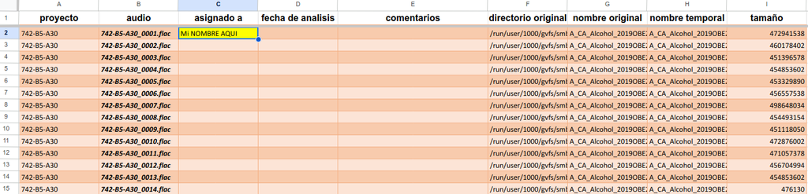

Si no le permite editar el archivo solicite el acceso haciendo click en el botón “solo lectura”:

[figure not shown]

2. Baje el archivo de la [carpeta compartida de audios](https://6f33fa7f78ea46e2aaca-my.sharepoint.com/:f:/g/personal/marcelo_araya_ucr_ac_cr/Er8ro9LYHc5EgtSPLqf4_g4BSrQL5qB37HJJ_LnIys1RoQ?e=edTXTO):
3. Abra el archivo en Raven Pro: Ctrl + O (or ir a “File” → “Open Sound Files…”).

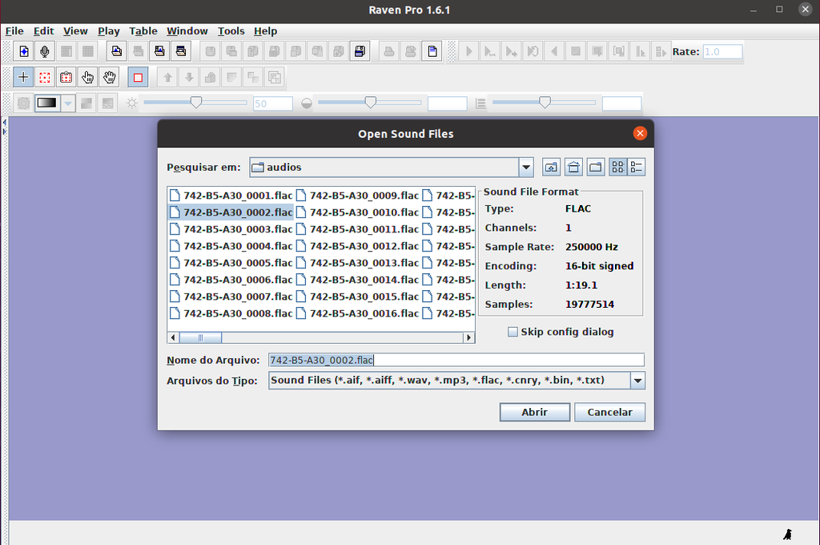

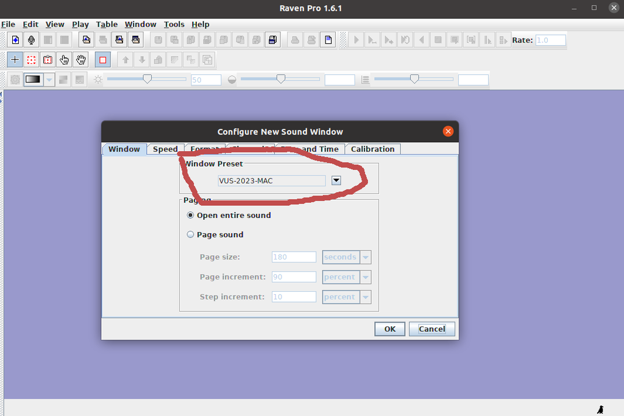

5. Si el archivo es muy pesado y su computadora tiene problemas abriéndolo pueden usar la opción “paging” para abrir los archivos gradualmente:

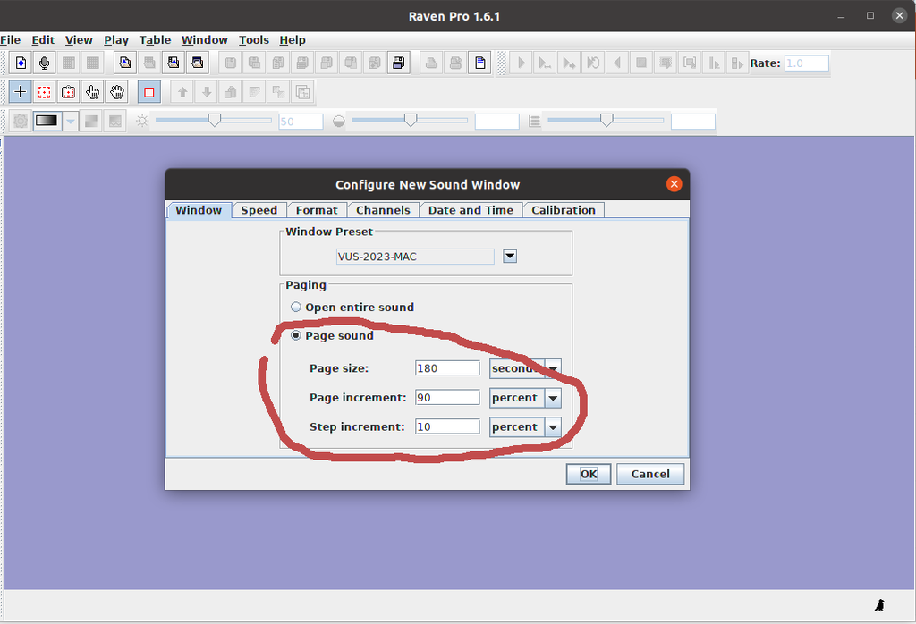

6. Puede modificar el contraste y brillo si le es difícil distinguir los sonidos:

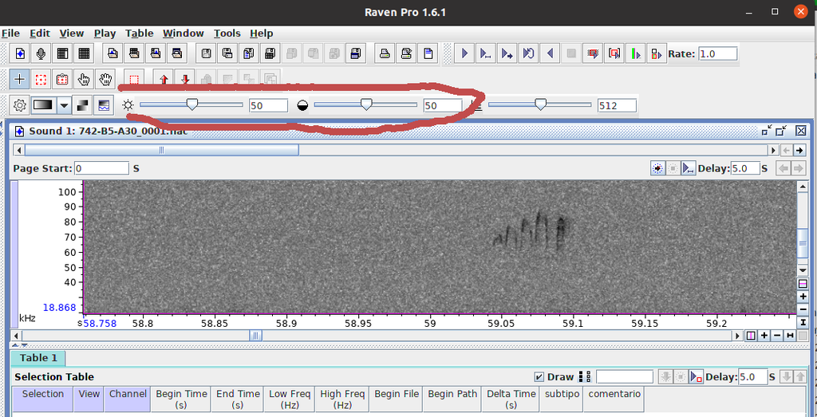

7. Asegúrese de que la resolución de los ejes de tiempo y frecuencia le permiten ver con claridad las señales. Idealmente el rango de frecuencia debe estar entre 18 y 100 kHz y mientras la resolución del tiempo debe ser cercana a 0.5 segundos:

[figure not shown]

8. El cuadro de selección debe contener las siguientes columnas:

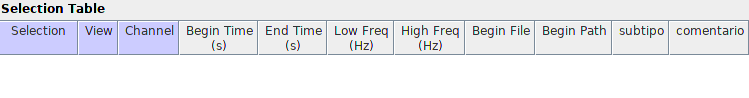

9. Debe clasificar cada sonido anotado en uno de los siguientes subtipos:

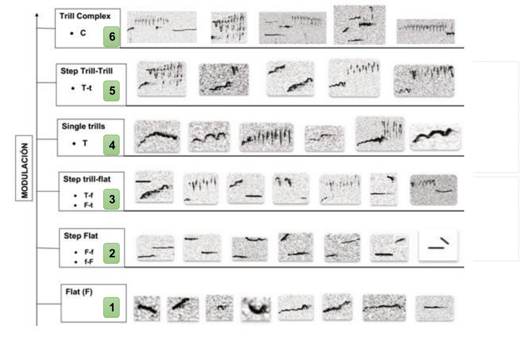

El número del subtipo debe anotarse en la columna “subtipo”. Cualquier duda sobre la anotación se puede escribir en la columna “comentario”.

10. Cuando haya terminado de anotar el archivo suba el archivo .txt a la [carpeta de anotaciones](https://www.dropbox.com/request/XxUYZOcIMWZNmWxS2OEn) (si no le permite editar haganos saber) y escriba la fecha en [hoja de anotaciones](https://docs.google.com/spreadsheets/d/1oNB9kOEIUy8QLAHQobm9EE4f47GmrbwAtTHT8yO9L2M/edit?usp=sharing):

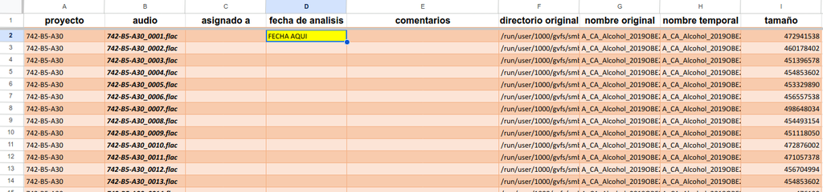

## Status

Este proyecto se encuentra: *en progreso*

## Contacto

Creado por Marcelo Araya-Salas